# DWEI5_Aula04_Flask-Projeto

[figure not shown]

Instituto Federal de São Paulo (IFSP)  
[Campus Bragança Paulista/SP](https://bra.ifsp.edu.br)  
**Análise e Desenvolvimento de Sistemas (ADS)**  
**5o. módulo**  
**Profa. Ana Paula Müller Giancoli**  
paulagiancoli@ifsp.edu.br

## AULA 04 - CRIANDO O PROJETO

### Agenda

- Estrutura Organizacional do Projeto
- Requisitos e Regras de Negócio
- Ambiente Virtual e instalações de dependências
- Editando arquivos do Projeto
- Perguntas

### 1. Estrutura organizacional do Projeto

### 1.1. Criando nosso Projeto

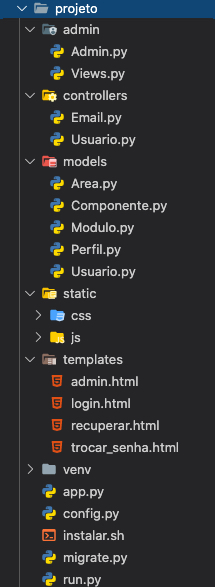

### 4.1. Requisitos e Regras de Negócio do nosso Projeto

- Seguindo os conceitos adquiridos, vamos criar um novo projeto na estrutura MVC. Importante salientar que há diversas formas de criação, o que dependerá do programador ou da especificação de cada projeto.
- **Requisitos** e **Regras de Negócio**:
  - O Administrador deverá ter permissão em todas as funcionalidades do aplicativo.
  - O Professor poderá criar, atualizar, listar e excluir as áreas, módulos, componentes curriculares.
  - O Aluno poderá apenas visualizar os componentes curriculares, além do seu próprio perfil.
  - O Visitante somente consulta nos componentes curriculares.
- **Views**:
  - Login: serão criadas as telas de login e recuperação de senha.
  - Usuários: serão criadas as telas de listagem de usuários, bem como as telas de edição, exclusão e criação de novos usuários.
  - Perfis: serão criadas as telas de acesso às configurações dos perfis dos tipos de perfis de acesso.
  - Áreas: serão criadas as telas de listagem de áreas, bem como as telas de edição, exclusão e criação de novas áreas.
  - Módulos: serão criadas as telas de listagem de módulos, bem como as telas de edição, exclusão e criação de novos módulos.
  - Componentes: serão criadas as telas de listagem de componentes, bem como as telas de edição, exclusão e criação de novos componentes curriculares.

### 1.1. Ambiente Virtual e instalações

- Lembre de criar o ambiente virtual **venv** dentro da pasta **projeto**.
- Para isso, de dentro da pasta **projeto**, execute:
  - **python3 -m venv venv**. (**Obs.**: Caso já tenha feito, não há necessidade de executar novamente, basta ativar o ambiente virtual.)
- Em seguida, inicie, ou melhor, ative o ambiente virtual **venv**, por meio:
  - **source venv/bin/activate**, conforme seu SO.
- Faça a instalação do Flask e demais dependências por meio da execução do arquivo criado na primeira aula: **instalar.bat** ou **instalar.sh**. (**IMPORTANTE**: **ambiente venv precisa estar ativo!!**).
- **Consulte: DWEI5_Aula01_IntroducaoFlask.html**
- Para executar:
  - Criar uma única vez e depois replicar nas pastas quando for necessário.
  - No Windows, criar o arquivo **instalar.bat** por meio de um editor de texto, e ao salvar, substituir .txt por .bat. (**Comando de execução de dentro do ambiente virtual ativo: dois cliques sobre instalar.bat**)
  - No MacOS, criar o arquivo **instalar.sh** por meio de um editor de texto, e ao salvar, substituir .txt por .sh. (**Comando de execução de dentro do ambiente virtual ativo: bash instalar.sh**)

### 2. Editando os arquivos do Projeto

### 2.1. Editando o arquivo config.py

- Localize o arquivo **config.py** dentro da pasta **projeto**.
- Abra e insira as instruções.
- No próprio arquivo foram inseridos o significado de cada instrução.

```
import os
import random, string


# Classe Config criada com as configurações do Projeto.
class Config(object):
    # Permite o uso de criptografia em sessões do Flask.
    CSRF_ENABLED = True

    # Palavra-chave secreta utilizada para criptografar chaves e valores, como por exemplo: senhas.
    SECRET = 'ysb_92=qe#dgjf8%0ng+a*#4rt#5%3*4kw5%i2bck*gn@w3@f&-&'

    # Caminho completo onde os templates estarão disponíveis no projeto.
    # Para capturar o endereco do arquivo atual: os.path.dirname(__file__)
    # Para capturar o caminho absoluto: os.path.abspath(variavel)
    # Para unir as strings: os.path.join(str1, str2)
    TEMPLATE_FOLDER = os.path.join(os.path.dirname(os.path.abspath(__file__)), 'templates')

    # Identificação do caminho completo do local do projeto
    ROOT_DIR = os.path.dirname(os.path.abspath(__file__))

    # Constante inicializada com None, posteriormente ao criar o app, esta será atribuída.
    APP = None

    # Variável com o endereço do banco de dados. O método .join é utilizado para
    # concatenar o nome completo contendo o endereço do banco de dados a ser utilizado pelo app.
    # O banco de dados será chamado de app.db. Pode ser utilizado qualquer nome.
    SQLALCHEMY_DATABASE_URI = 'sqlite:///' + os.path.join(ROOT_DIR, 'app.db')

    # CHAVE API COPIADA DO SITE - UNICA PARA CADA UM ** OMITIR ANTES DE DIVULGAR CODIGO ***
    # Inserida para enviar email por meio do serviço sendgrid. (veremos mais adiante)
    SENDGRID_API_KEY = 'Copiar a chave do site'

# Classe Development herda da classe Config, e foi criada com as configurações do Projeto para ambiente de Desenvolvimento.
class Development(Config):
    # Habilitando o modo de teste.
    TESTING = True

    # Habilitando o modo de debug.
    DEBUG = True

    # Definindo o IP do servidor Flask.
    IP_HOST = 'localhost'

    # Definindo a PORTA de acesso do servidor Flask.
    PORT_HOST = 8000

    # Definindo a URL root da aplicação Flask.
    URL_MAIN = 'http://%s:%s/' % (IP_HOST, PORT_HOST)


# Classe TestingConfig herda da classe Config, e foi criada com as configurações do Projeto para ambiente de Teste.
class TestingConfig(Config):
    TESTING = True
    DEBUG = True

    # Aqui geralmente é um IP de um servidor na nuvem e não o endereço da máquina local.
    IP_HOST = 'localhost'

    PORT_HOST = 5000
    URL_MAIN = 'http://%s:%s/' % (IP_HOST, PORT_HOST)


# Classe Production herda da classe Config, e foi criada com as configurações do Projeto para ambiente de Produção.
class Production(Config):
    DEBUG = False
    TESTING = False

    # Aqui geralmente é um IP de um servidor na nuvem e não o endereço da máquina local.
    IP_HOST = 'localhost'

    PORT_HOST = 8080
    URL_MAIN = 'http://%s:%s/' % (IP_HOST, PORT_HOST)

# Variável com as 3 configurações dos ambientes. Será utilizada para saber qual ambiente estamos utilizando.
app_config = {
    'development': Development(),
    'testing': TestingConfig(),
    'production': Production()
}

# Variável que receberá o valor do ambiente que está ativo e em uso. O método os.getenv('NOME_DA_CHAVE'). Onde NOME_DA_CHAVE é o nome da variável de ambiente, neste caso FLASK_ENV. Esta variável receberá o tipo de ambiente que está sendo utilizado antes da execução do arquivo run.py. Deve ser informada uma única vez. Porém todas as vezes que o ambiente virtual for ativado. E sempre antes de exeutar o run.py.
app_active = os.getenv('FLASK_ENV')
```

### 2.2. Editando o arquivo app.py

- Localize o arquivo **app.py** dentro da pasta **projeto**.
- Abra e insira as instruções.
- No próprio arquivo foram inseridos o significado de cada instrução.

```
# Ao inserir esta primeira linha (# -*- coding: utf-8 -*-) no arquivo, estamos indicando que o mesmo deve utilizar a codificação utf-8, no caso para nosso idioma que possui acentos.

# -*- coding: utf-8 -*-

# É importado da biblioteca flask, a classe Flask.
from flask import Flask

# É importado do arquivo config.py, as variáveis app_config, app_active que app_config: possui as configurações e o tipo de ambiente a ser utilizado (Desenvolvimento, Teste ou Producao). E app_active: possui as configurações de qual ambiente está sendo utilizado por meio da variável de ambiente FLASK_ENV.
from config import app_config, app_active

# A variável config recebe a atribuição do ambiente ativo.
config = app_config[app_active]

# Método create_app que recebe como argumento com todas as configurações da aplicação.
def create_app(config_name):

    # A variável app recebe uma instância de Flask, passando a configuração da localização dos templates. Pode
    # receber diversas configurações.
    app = Flask(__name__, template_folder='templates')

    # O atributo secret_key da aplicação app, recebe a configuração da chave secreta do arquivo config.py, por meio da variável config e atributo SECRET.
    app.secret_key = config.SECRET

    # Efetua o carregamento do arquivo config.py
    app.config.from_object(app_config[config_name])
    app.config.from_pyfile('config.py')

    # Primeira rota a ser criada. A rota principal root.
    # Quando se cria duas ou mais rotas seguidas antes do método, isso indica ao navegador que qualquer uma delas acessa o método a seguir. Neste exemplo tanto http://localhost:8000/ e http://localhost:8000/login/ acessam o médtodo index(). Que retorna uma string.
    @app.route('/')
    @app.route('/login/')
    def index():
        return 'Meu Primeiro APP Flask!'


    # Retorno do método create_app(). Retorna a instância do app criada.
    return app
```

### 2.3. Editando o arquivo run.py

- Localize o arquivo **run.py** dentro da pasta **projeto**.
- Abra e insira as instruções.
- No próprio arquivo foram inseridos o significado de cada instrução.

```
# Importa a biblioteca que permite a execução de intruções no sistema.
import sys

# do pacote app.py importa o método create_app, o qual criará uma instância da aplicação.
from app import create_app

# do módulo config importa o as variáveis app_config, app_active que possuem as configurações do ambiente.
from config import app_config, app_active

# Importa da biblioteca importlib, o método reload para que a cada alteração em algum arquivo, o servidor Flask seja reiniciado.
from importlib import reload

# A variável config foi criada para receber o ambiente ativo.
config = app_config[app_active]

# A variável config.APP, APP constante definida no arquivo config.py foi criada para receber a aplicação ativa. A aplicação ativa, é definida no arquivo app.py e importada pelo run.py.
config.APP = create_app(app_active)

# Verificar se o arquivo run.py está sendo executado de forma direta ou não. Se for importado, o if não será executado. Para que seja executado: no terminal digitar python run.py de dentro da pasta projeto.
# Ao ser executado diretamente run.py, será iniciado o servidor Flask. com as configurações definidas no arquivo config.py para o ip do host e porta.
if __name__ == '__main__':
    config.APP.run(host=config.IP_HOST, port=config.PORT_HOST)
    # executado sempre que ocorrer alguma alteração em um arquivo do projeto.
    reload(sys)
```

### 2.4. Testando nossa aplicação inicial

- **LEMBRANDO**:
  - Para criar um **ambiente virtual**, digite no terminal, dentro da pasta **projeto**:
    - **python -m venv venv**
  - No terminal, ative o ambiente virtual, de dentro da pasta **projeto**:
    - **source venv/bin/activate**, conforme seu SO.
  - Se não tiver instalado as bibliotecas necessárias para o Flask, verifique se o ambiente virtual está ativo, e execute o arquivo criado na primeira aula.
- Em seguida, ainda na pasta **projeto**, digite o valor que deve ser atribuída à variável de ambiente FLASK_ENV (não deixe espaços). De acordo com a documentação de Flask, deve ser **FLASK_ENV=development**:
  - **export FLASK_ENV=development**. **OBS**: de acordo com [Pallets Project](https://flask.palletsprojects.com/en/1.1.x/config/), para o WINDOWS, substitua a palavra **export** por **set**.
- Observe que **development** foi o valor que informamos no arquivo **config.py**, e é a palavra-chave utilizada pelo Flask para identificar o ambiente como um ambiente de desenvolvimento:

```
# projeto/config.py
# Variável com as 3 configurações dos ambientes. Será utilizada para saber qual ambiente estamos utilizando.
app_config = {
    'development': Development(),
    'testing': TestingConfig(),
    'production': Production()
}
```

- Para **executar o servidor FLASK**, de dentro da pasta **projeto**, digite:
  - **python run.py**
- Serão exibidas as **seguintes linhas no terminal** indicando que o servidor Flask está funcionando e no modo Debug.
- Caso queira encerrar o servidor, no terminal, pressione **CTRL+C**.
- Caso não deseja continuar com o desenvolvimento e testes, desative o ambiente virtual, digitando no terminal: **deactivate**.

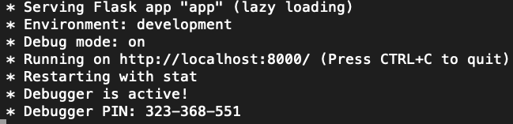

- Copie e cole no navegador: http://localhost:8000/.
- Verifique se aparecerá:

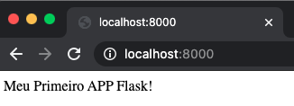

### ATENÇÃO

- **Lembre-se de encerrar o servidor ao final de cada aula**.
- **Lembre-se também, de desativar o ambiente virtual**.

### Referências

- Esta aula foi elaborada a partir do conteúdo disponibilizado em cada um dos links indicados no próprio texto.

### Perguntas

- Esclareça suas eventuais dúvidas durante as aulas.
- Ou pelo *E-mail*: paulagiancoli@ifsp.edu.br.
- Ou acesse [Github Ana Giancoli](https://anagiancoli.github.io) e solicite atendimento para o componente curricular.

*ADS - HTML5, CSS3, JS, FLASK - 5o. módulo*.  
Modelo e formato elaborado por profa. Ana Paula Müller Giancoli - BSD 2-Clause License. - Fevereiro.2021.